# Dynamiques globales : Analyse du développement socioéconomique des pays de 1880 à 2010

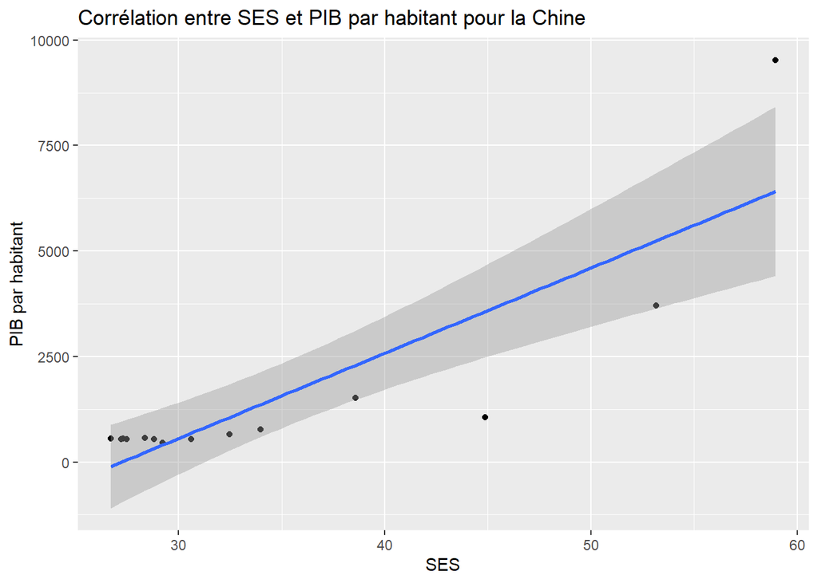

```r
# Nuage de points entre SES et PIB par habitant
ggplot(data_china, aes(x = SES, y = gdppc)) +
  geom_point() +
  geom_smooth(method = "lm") +
  labs(title = "Corrélation entre SES et PIB par habitant pour la Chine",
       x = "SES",
       y = "PIB par habitant")
```

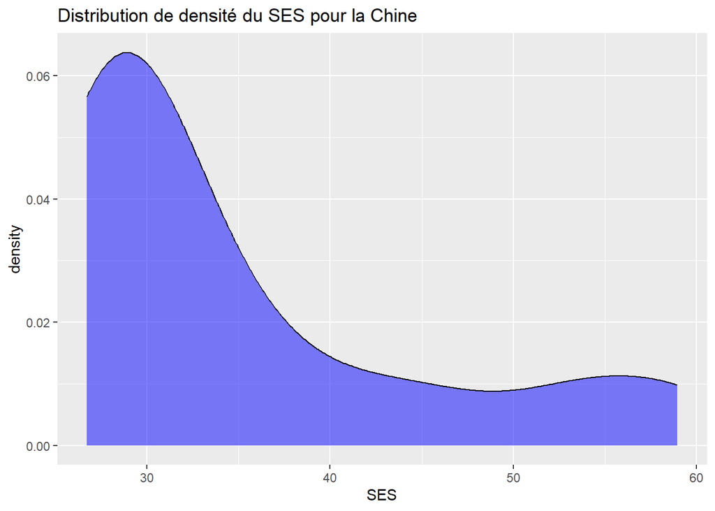

```r
# Visualiser les distributions
# Distribution du SES
ggplot(data_china, aes(x = SES)) +
  geom_density(fill = "blue", alpha = 0.5) +
  labs(title = "Distribution de densité du SES pour la Chine", x = "SES")
```

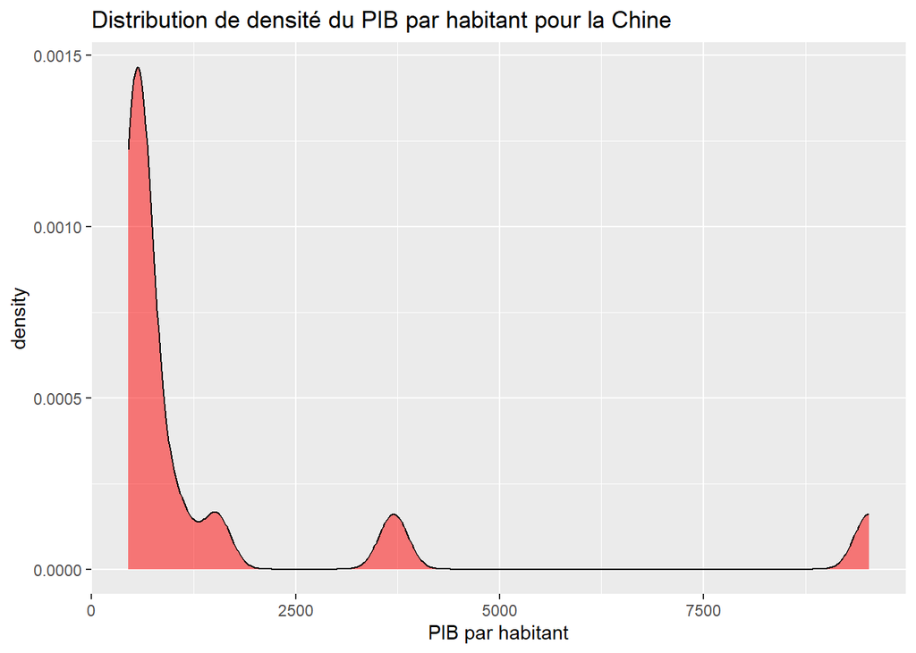

```r
# Distribution du PIB par habitant
ggplot(data_china, aes(x = gdppc)) +
  geom_density(fill = "red", alpha = 0.5) +
  labs(title = "Distribution de densité du PIB par habitant pour la Chine", x = "PIB par habitant")
```

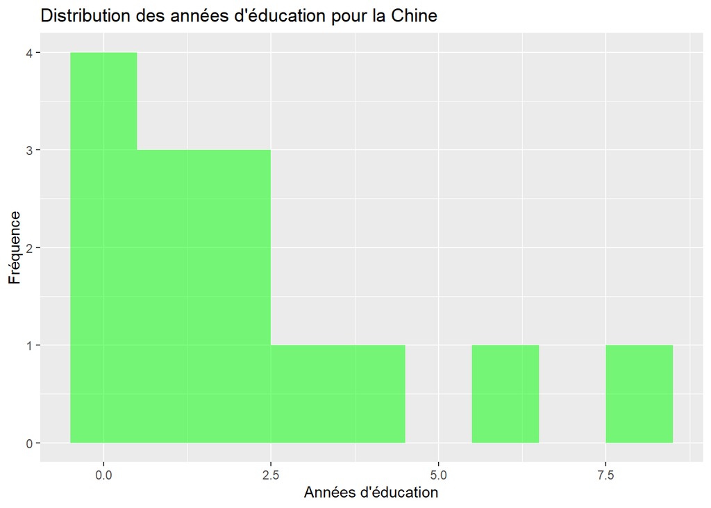

```r
# Distribution des années d'éducation
ggplot(data_china, aes(x = yrseduc)) +
  geom_histogram(binwidth = 1, fill = "green", alpha = 0.5) +
  labs(title = "Distribution des années d'éducation pour la Chine", x = "Années d'éducation", y = "Fréquence")
```

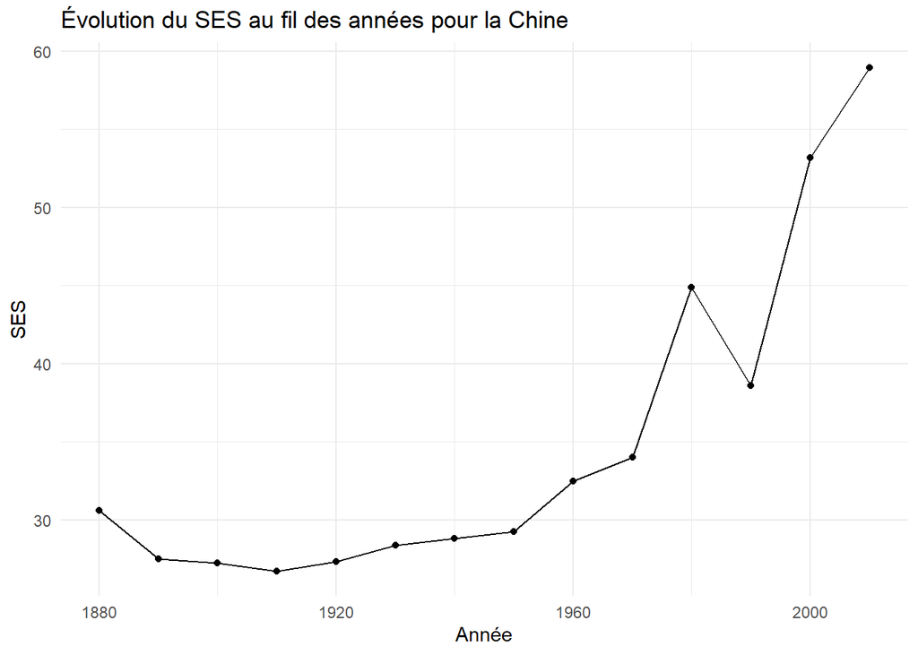

```r
# Evolution du SES au fil des ans
ggplot(data_china, aes(x = year, y = SES)) +
  geom_line() +
  geom_point() +
  labs(title = "Évolution du SES au fil des années pour la Chine",
       x = "Année",
       y = "SES") +
  theme_minimal()
```

```r
# Filtrer les données pour la Chine uniquement
data_china <- completedData %>% filter(country == "China")

# Calculer les statistiques descriptives pour les colonnes sélectionnées
descriptive_stats <- data_china %>%
  summarise(across(c(yrseduc, SES, gdppc, popshare),
                   list(Mean = ~mean(., na.rm = TRUE),
                        SD = ~sd(., na.rm = TRUE),
                        Median = ~median(., na.rm = TRUE),
                        Min = ~min(., na.rm = TRUE),
                        Max = ~max(., na.rm = TRUE))))

# Afficher les statistiques descriptives
print(descriptive_stats)
```

```
##   yrseduc_Mean yrseduc_SD yrseduc_Median yrseduc_Min yrseduc_Max SES_Mean
## 1     2.164536   2.379869         1.4303        0.13        8.22 34.84641
##    SES_SD SES_Median  SES_Min  SES_Max gdppc_Mean gdppc_SD gdppc_Median
## 1 10.3759   29.92492 26.72672 58.95216   1538.552 2451.082     562.1875
##   gdppc_Min gdppc_Max popshare_Mean popshare_SD popshare_Median popshare_Min
## 1       448  9525.819     0.2312779   0.0171169       0.2274937    0.1985164
##   popshare_Max
## 1    0.2639208
```

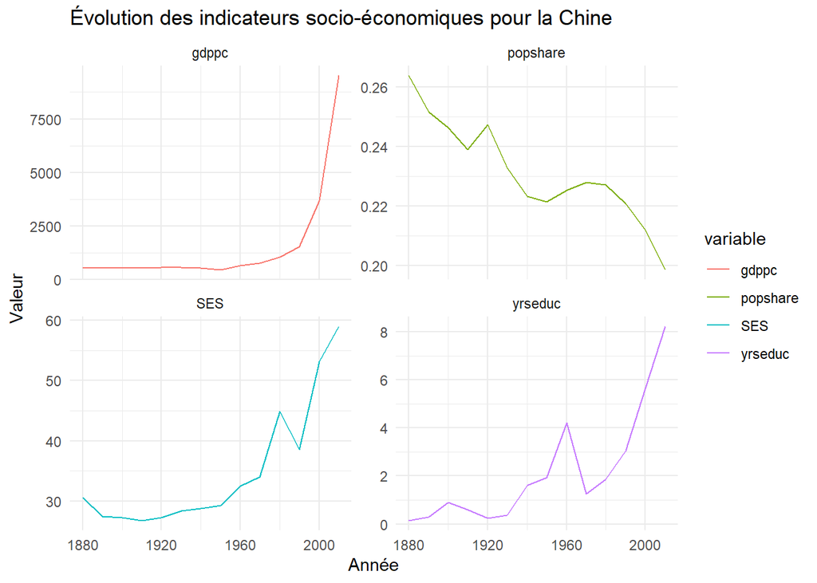

```r
# Assurez-vous que vos données sont correctement filtrées pour la Chine
data_china <- completedData %>%
  filter(country == "China") %>%
  select(year, yrseduc, SES, gdppc, popshare)

# Préparez les données en format long pour le traçage
data_china_long <- pivot_longer(data_china,
                                cols = c(yrseduc, SES, gdppc, popshare),
                                names_to = "variable",
                                values_to = "value")

# Créez un graphique avec une grille pour chaque variable, spécifiant que c'est pour la Chine
ggplot(data_china_long, aes(x = year, y = value, color = variable)) +
  geom_line() +
  facet_wrap(~variable, scales = "free_y") +
  labs(x = "Année", y = "Valeur", title = "Évolution des indicateurs socio-économiques pour la Chine") +
  theme_minimal()
```

# Analyse des tendances socioéconomiques en Chine

**Évolution de l’éducation en Chine de 1880 à 2000**

L’histoire éducative de la Chine entre 1880 et 2000 illustre une transformation profonde, marquée par un accroissement notable du nombre moyen d’années d’éducation, une mesure clé de l’accès et de la qualité de l’éducation dans le pays (Lee & Zeitzoff 2020, 1-14). Initialement, les années moyennes d’éducation étaient extrêmement faibles, avec des chiffres avoisinant les 0,13 année en 1880, ce qui reflète les conditions préindustrielles et la structure principalement agraire de la société chinoise de l’époque.

**PIB par habitant**

En termes de croissance économique, la Chine a connu un essor remarquable, comme en témoigne l’augmentation spectaculaire de son PIB par habitant, de 448 USD à 9525,82 USD. Cette croissance, particulièrement évidente après les réformes économiques de la fin du XXe siècle, illustre la transformation radicale de l’économie chinoise d’une structure agraire à une puissance industrielle et technologique mondiale. Néanmoins, il est crucial de noter que les avantages de cette croissance n’ont pas été uniformément répartis, comme l’indique la distribution inégale du PIB par habitant (Sicular et al. 2007, 93-111).

**Corrélations et implications**

Les analyses montrent des corrélations positives entre l’éducation, le SES et le PIB par habitant en Chine. L’interdépendance de ces facteurs met en évidence l’importance cruciale de l’éducation dans la promotion de la croissance économique et l’amélioration du statut socio-économique. L’investissement dans l’éducation se traduit par une main-d’œuvre plus qualifiée et plus productive, favorisant ainsi la croissance économique et l’élévation des niveaux de vie (Zhuang et al., 2022).

**Conclusion**

La Chine a traversé des changements socio-économiques significatifs au cours des derniers siècles, caractérisés par des avancées notables dans l’éducation et le bien-être général de sa population. Ces progrès ont joué un rôle déterminant dans le développement et la modernisation économique du pays. Cependant, malgré ces succès, des défis subsistent, notamment les disparités régionales et les inégalités de revenu. Pour un développement futur plus équilibré et inclusif, ces enjeux nécessiteront des politiques bien conçues et ciblées, mettant l’accent sur la réduction des inégalités et la promotion d’une croissance partagée.

# Conclusions et perspectives sur le développement socioéconomique global (1880-2010)

Cette analyse approfondie des dynamiques socioéconomiques de 1880 à 2010 illustre l’impact significatif de l’éducation et du PIB par habitant sur le développement des nations, tout en mettant en lumière les disparités régionales et la nécessité d’interventions ciblées. Les résultats soulignent l’importance d’une croissance inclusive, encouragent l’adoption de politiques intégrées et suggèrent des mesures spécifiques pour améliorer le SES. Malgré certaines zones nécessitant plus d’attention, identifiées par les diagnostics de régression multivariée, l’étude affirme la valeur de ses conclusions et pose des bases pour de futures recherches. En somme, cette recherche confirme la complexité des liens entre éducation, SES, et développement économique, et recommande des politiques nuancées, adaptées aux réalités spécifiques de chaque pays, pour un développement socioéconomique durable et équitable.

# Bibliographie

```
American Psychological Association. (s. d.). Éducation et statut socioéconomique. Récupéré de : https://www.apa.org/topics/socioeconomic-status

Bacha, E.L & Greenhill, R. (1992). Why did Brazil reform?. Finance & Development, 29(2), 35-38.

Barro, R. J., & Lee, J. W. (2013). A new data set of educational attainment in the world, 1950–2010. Journal of Development Economics, 104, 184-198. https://www.sciencedirect.com/science/article/pii/S0304387812000855

Bejaković, P. (2004). Education and socio-economic reforms. Dans S. Vidović (Éd.), Croatia: Faced with the challenge of socio-economic reform (pp. 91-109). Friedrich Ebert Stiftung.

Bramall, C. (2008). Chinese Economic Development. Routledge. (Chapitres 2 et 3). https://www.taylorfrancis.com/books/mono/10.4324/9780203890820/chinese-economic-development-chris-bramall

Burdisso, T., Sangiovannie, L., & Tomasangelo, M. (2004). La crisis de la convertibilidad en Argentina (1991-2002). Cuadernos del CEMLA, 50, 315-415.

 China Education Center. "China's Education Modernization 2035." China Education Center, 2024. Récupéré de : https://www.chinaeducenter.com/en/cedu/2035plan.php

Di Tella, G. (1983). Argentina under Perón, 1973–76: The Nation's Experience with a Labour-Based Government. Macmillan International Higher Education.

Farzanegan, M. R., & Markwardt, G. (2018). Development and Emergence of Non-Oil Economic Sectors: A New Hope for the Future of Iran's Economy? The World Economy, 41(2), 274–301.

Ferreira, F.H.G., Leite, P.G., & Ravallion, M. (2010). La liberté gagnante contre la pauvreté? Un aperçu empirique. Review of Income and Wealth, 56(1), 39-66.

Fforde, A., & De Vylder, S. (1996). From plan to market: The economic transition in Vietnam. Routledge (pp. 24-39). https://www.taylorfrancis.com/books/mono/10.4324/9780429039966/plan-market-adam-fforde

FMI (2022). Argentina: 2022 Article IV Consultation. https://www.imf.org/en/Publications/CR/Issues/2022/07/15/Argentina-2022-Article-IV-Consultation-Press-Release-Staff-Report-and-Statement-by-the-520453

Frenkel, R. & Rapetti, M. (2010). A concise history of argentine's decade. Dans Time for Argentina's Revival? (pp. 3-46). Brookings Institution Press.

Gerchunoff, P. & Llach, L. (2005). El ciclo de la ilusión y el desencanto. Un siglo de políticas económicas argentinas. Ariel. https://www.academia.edu/83906761/Gerchunoff_P_y_Llach_L_El_ciclo_de_la_ilusi%C3%B3n_y_el_desencanto_Un_siglo_de_pol%C3%ADticas_econ%C3%B3micas_argentinas

Hanushek, E. A., & Wößmann, L. (2007). The role of education quality for economic growth (No. 4122). World Bank Policy Research Working Paper. https://openknowledge.worldbank.org/handle/10986/7154

Hauser, R. M. "Measuring socioeconomic status in studies of child development." Child Development, 65(6), 1541-1545 (1994). Organisation for Economic Cooperation and Development (OECD). "Scaling Procedures and Construct Validation of Context Questionnaire Data" (2017).

Hillbom, E. (2008). Diamonds or development? A structural assessment of Botswana's forty years of success. The Journal of Modern African Studies, 46(2), 191-214. https://www.researchgate.net/publication/231955101_Diamonds_or_development_A_structural_assessment_of_Botswana%27s_forty_years_of_success

Lee, J. & Zeitzoff, T. (2020). Education and Human Capital in China. Asian Development Review, 37(1), 1-34. https://www.adb.org/publications/education-and-human-capital-development-china

Lee, K. (2021). La volonté de devenir une économie avancée: les déterminants du changement structurel en Corée. Techniques Financières et Développement, 68(2), 22-40.

Lee, K., Woo, W., & Jang, H. (2019). Critical issues in South Korea's rise to an ICT power. Telecommunications Policy, 43(5), 391-405.

```

[output cut: 34 more lines]

```
Sirin, S. R. (2005). Socioeconomic status and academic achievement: A meta-analytic review of research. Review of Educational Research, 75(3), 417-453. https://psycnet.apa.org/record/2005-11732-004

State Council of the People's Republic of China. "2 plans detail China’s goals for education." China Daily, updated Feb 25, 2019. Lien. https://english.www.gov.cn/policies/policy_watch/2019/02/25/content_281476537597482.htm

Stiglitz, J., Sen, A., & Fitoussi, J.P. (2009). Rapport de la Commission sur la mesure des performances économiques et du progrès social. https://www.economie.gouv.fr/files/finances/presse/dossiers_de_presse/090914rapport_comission_stiglitz.pdf

Vega, J. (2005). Inversión pública en educación básica y su impacto en la pobreza. Dans PNUD/Alfaomega (Éd.), Inversión pública en educación básica y pobreza en el Perú (pp. 28-42). PNUD/Alfaomega.

Vos, R., Ganuza, E., Morley, S., & Robinson, S. (Eds.). (2006). ¿Quién se beneficia del libre comercio? Promoción de exportaciones en América Latina y el Caribe en los 90. PNUD/Alfaomega (pp. 145-187). https://www.ifpri.org/publication/%c2%bfqui%c3%a9n-se-beneficia-del-libre-comercio

Xue, E., Li, J., & Li, X. (2021). Sustainable Development of Education in Rural Areas for Rural Revitalization in China: A Comprehensive Policy Circle Analysis. Sustainability, 13(23), 13101. Récupéré de : https://www.mdpi.com/2071-1050/13/23/13101

Zhao Yimeng. (2023). Rural education reforms in spotlight at expo. Chinadaily.com.cn. Récupéré de : https://www.chinadaily.com.cn/a/202311/20/WS655b14e7a31090682a5ef1e5.html

Zhuang, J., Shi, L. & Dingar, S. (2022). Inequality in China: Trends, Drivers and Policy Remedies. Asian Development Bank Institute. https://www.adb.org/publications/inequality-china-trends-drivers-policy-remedies
```